# Análisis de Tweets de la Municipalidad de La Plata

Proyecto PIDAE-UBA “Separacion de residuos, desarrollo sustentable y políticas”. Centro de Transferencia de Conocimiento y Tecnología (CETCOT - UBA)

GICP Ciencia de Datos, Análisis de Redes y Gestión del Desarrollo Tecnológico

Agosto 2022

## Presentación

La idea de esta serie de publicaciones es mostrar algunas tecnicas útiles para el análisis de tweets. En esta ocasión el objeto de estudio serán instituciones políticas relevantes con la idea de explorar su comportamiento en Twitter explorando por un lado los números de sus actividades en la red y la repercusión de sus mensajes y, por el otro, las palabras utilizadas para conformar el mensaje que desean emitir. En este orden de ideas, la dinamica de trabajo será primero abordar el análisis cuantitativo de los números que obtienen los mensajes de estas figuras, para lo cual elaboraremos una función que levantará las bases según el usuario deseado y limpiará la misma. Las bases de trabajo fueron conformadas mediante la descarga de tweets a través del paquete Rtweet [git](https://rtweet.info/). El análisis de sentimiento se determinó mediante el diccionario SDAL.

El trabajo se enmarca dentro del Proyecto de Investigación y Desarrollo en Áreas Estratégicas (PIDAE) “Separacion de residuos, desarrollo sustentable y políticas” en el cual ha investigado la comunicación en redes sociales de diferentes instituciones y figuras políticas, especialmente en temas referidos al desarrollo sustentable. La presente publicación es un aporte al proyecto por parte del Grupo de Investigación en Ciencia Política “Ciencia de Datos, Análisis de Redes y Gestión del Desarrollo Tecnológico” en el cual los investigadores en formación han podido aplicar las herramientas de análisis adquiridas en las capacitaciones del GICP, brindada a través de la plataforma La UNX, desarrollada por CETCOT - ACDES.

# Descriptivos

La Base del usuario LaPlataMLP contiene un total de 3250 de tweets publicados desde 2020-05-25 hasta 2022-08-18.

[interactive chart not shown]

Veamos ahora cual es la frecuencia de las interacciones según la hora del día

[interactive chart not shown]

Ahora agreguemos al análisis la desagregación según dispositivo

```
## Rows: 5
## Columns: 3
## $ source <chr> "Periscope", "TweetDeck", "Twitter for Android", "Twitter for i…
## $ total  <int> 2, 33, 1, 1607, 1607
## $ prop   <dbl> 0.06153846, 1.01538462, 0.03076923, 49.44615385, 49.44615385
```

[interactive chart not shown]

Tambien podemos ver los mensajes mas retuiteados y faveados

| status_id | text | favorite_count | Fecha_corta | ext_media_expanded_url |
| --- | --- | --- | --- | --- |
| 1497995602164023296 | 💛💙 Україно ми з тобою ☮️ https://t.co/vQYgp4ok2L | 1344 | 2022-02-27 | https://twitter.com/LaPlataMLP/status/1497995602164023299/photo/1 |

| status_id | text | retweet_count | Fecha_corta | ext_media_expanded_url |
| --- | --- | --- | --- | --- |
| 1497995602164023296 | 💛💙 Україно ми з тобою ☮️ https://t.co/vQYgp4ok2L | 316 | 2022-02-27 | https://twitter.com/LaPlataMLP/status/1497995602164023299/photo/1 |

# Nube de palabras

Una buena manera de representar las palabras utilizadas consiste en conformar las nubes de palabras o bag of words. Basicamente se trata de visualizar cuales son los términos de mayor uso mostrando su peso en relación a los otros.

Esta es la nube de palabras del año en Twitter de LaPlataMLP

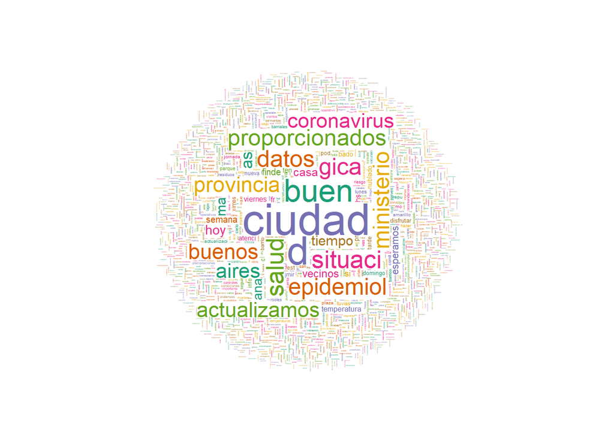

Palabras positivas

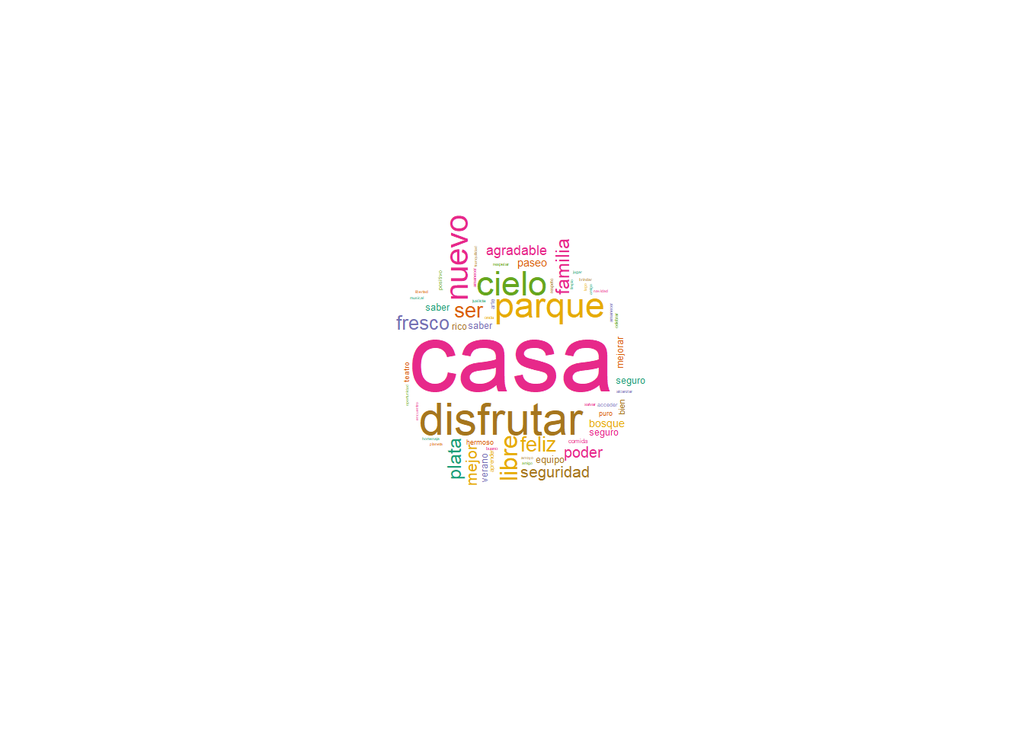

Palabras negativas

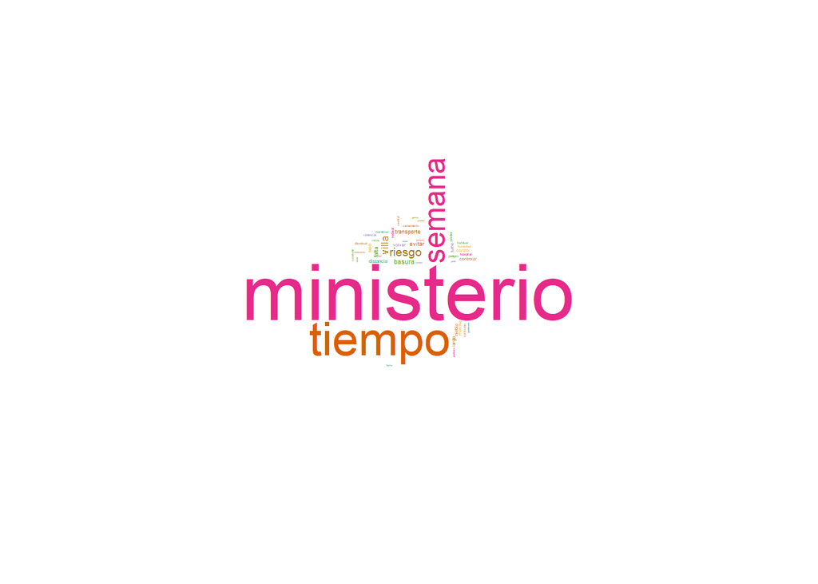

[interactive chart not shown]

## Captura de tweet con mayor cantidad de favs:

[figure not shown]

## Captura de tweet con mayor cantidad de rt:

[figure not shown]

Finalmente agregamos un cuadro resumen con la cantidad de palabras utilizadas vinculadas al medio ambiente

| Palabra | Cantidad |
| --- | --- |
| residuos | 67 |
| basura | 34 |
| reciclar | 14 |
| ambiente | 5 |
| reciclaje | 5 |
| ambiental | 3 |